# Limitations in ADLs - Shopping for groceries

# 1 Description of DataSchema variable

The description of harmonised variable is the following:

- Short name: `iadl_shopping`
- Variable label: `IADL - Difficulties for shopping groceries`
- Variable description: `IADL - Difficulties for shopping groceries`
- Domain: `Health status and functional limitations`
- Value type: `categorical`
- Category coding:

| **Code** | **Category Label** |
| --- | --- |
| 0 | Yes |
| 1 | No |

- Category missings:

| **Code** | **Category Label** |
| --- | --- |
| 991 | CAPI/interviewer error |
| 992 | Impute |
| 993 | Disable to measure |
| 994 | Not applicable |
| 995 | Does not answer |
| 996 | Not attempt/not done |
| 997 | Refuse |
| 998 | Do not know |
| 999 | Missing |

# 2 Data process

## 2.1 ELSA

### 2.1.1 Wave 1

#### 2.1.1.1 Study-specific variable description

The study-specific variables elected to be harmonised is:

- Name: `headlsh`
- Label: `IADL: Difficulty shopping for groceries`
- Categories:
- `0 = Not mentioned`
- `1 = Mentioned`
- Missings
- `-9 = Refusal`
- `-8 = Don't know`
- `-1 = Not applicable`

IADL - Difficulties for shopping groceries

| Sample size | Missing values |
| --- | --- |
| 12099 | 191 |

Category

|  | 0 | 1 |
| --- | --- | --- |
| Frequency | 10801.00 | 1107.00 |
| Percentage | 89.27 | 9.15 |

Type of missing

|  | -1 | -9 | -8 | NA |
| --- | --- | --- | --- | --- |
| Frequency | 175.00 | 4.00 | 12.0 | 0 |
| Percentage | 1.45 | 0.03 | 0.1 | 0 |

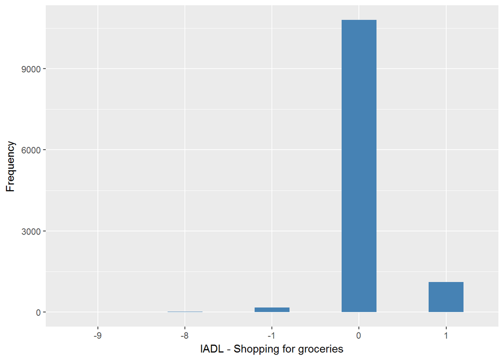

#### 2.1.1.2 Harmonisation algorithm

To compute the harmonize variable from the study-specific variable it has to be recoded as follows:

- `1 into 0`
- `0 into 1`
- `-9 Refusal into 997`
- `-8 Don't know into 998`
- `-1 Not applicable into 994`

**R script:**

```r
ELSA_ds_w1 <- tibble(id=ELSA_w1_iadl_shopping$id)
ELSA_ds_w1$iadl_shopping <- car::recode(ELSA_w1_iadl_shopping$headlsh, "0 = '1';1 = '0';-9 = '997';-8 = '998';-1 = '994' ")
ELSA_ds_w1$iadl_shopping <- labelled(ELSA_ds_w1$iadl_shopping, labels = c("Yes"=0, "No"=1,"Missing"=999, "Do not know"=998, "Refuse"=997, "Not applicable"=996, "Does not answer"=995,  "Not attempt not done"=994, "Disable to measure"=993, "Impute"=992, "CAPI interviewer error"=991))
```

#### 2.1.1.3 Statistical description of the new harmonised variable

IADL - Difficulties for shopping groceries

| Sample size | Missing values |
| --- | --- |
| 12099 | 191 |

Category

|  | 0 | 1 |
| --- | --- | --- |
| Frequency | 1107.00 | 10801.00 |
| Percentage | 9.15 | 89.27 |

Type of missing

|  | 991 | 992 | 993 | 994 | 995 | 996 | 997 | 998 | 999 | NA |
| --- | --- | --- | --- | --- | --- | --- | --- | --- | --- | --- |
| Frequency | 0 | 0 | 0 | 175.00 | 0 | 0 | 4.00 | 12.0 | 0 | 0 |
| Percentage | 0 | 0 | 0 | 1.45 | 0 | 0 | 0.03 | 0.1 | 0 | 0 |

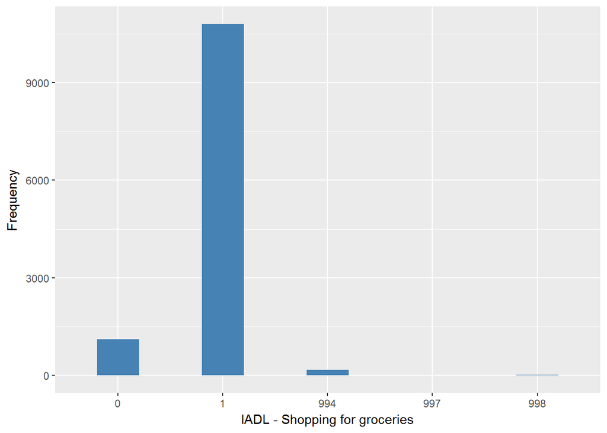

#### 2.1.1.4 Validation

|  | 1->0 | 0->1 | -1->994 | -9->997 | -8->998 |
| --- | --- | --- | --- | --- | --- |
| BeforeH | 1107 | 10801 | 175 | 4 | 12 |
| AfterH | 1107 | 10801 | 175 | 4 | 12 |

### 2.1.2 Wave 2

#### 2.1.2.1 Study-specific variable description

The study-specific variables elected to be harmonised is:

- Name: `headlsh`
- Label: `IADL: Difficulty shopping for groceries`
- Categories:
- `0 = Not mentioned`
- `1 = Mentioned`
- Missings
- `-9 = Refusal`
- `-8 = Don't know`

IADL - Difficulties for shopping groceries

| Sample size | Missing values |
| --- | --- |
| 9432 | 3 |

Category

|  | 0 | 1 |
| --- | --- | --- |
| Frequency | 8496.00 | 933.00 |
| Percentage | 90.08 | 9.89 |

Type of missing

|  | -1 | -9 | -8 | NA |
| --- | --- | --- | --- | --- |
| Frequency | 0 | 2.00 | 1.00 | 0 |
| Percentage | 0 | 0.02 | 0.01 | 0 |

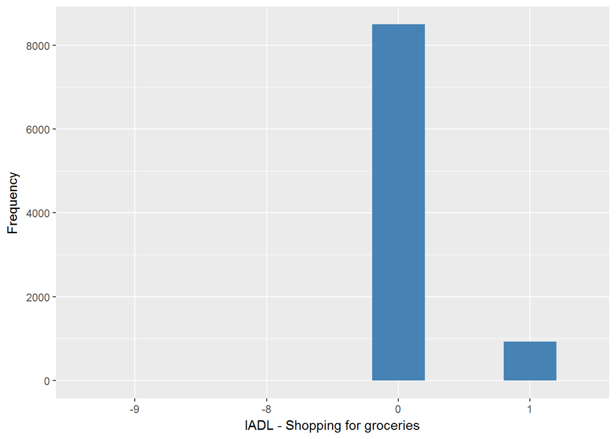

#### 2.1.2.2 Harmonisation algorithm

To compute the harmonize variable from the study-specific variable it has to be recoded as follows:

- `1 into 0`
- `0 into 1`
- `-9 Refusal into 997`
- `-8 Don't know into 998`

**R script:**

```r
ELSA_ds_w2 <- tibble(id=ELSA_w2_iadl_shopping$id)
ELSA_ds_w2$iadl_shopping <- car::recode(ELSA_w2_iadl_shopping$headlsh, "0 = '1';1 = '0';-9 = '997';-8 = '998';-1 = '994' ")
ELSA_ds_w2$iadl_shopping <- labelled(ELSA_ds_w2$iadl_shopping, labels = c("Yes"=0, "No"=1,"Missing"=999, "Do not know"=998, "Refuse"=997, "Not applicable"=996, "Does not answer"=995,  "Not attempt not done"=994, "Disable to measure"=993, "Impute"=992, "CAPI interviewer error"=991))
```

#### 2.1.2.3 Statistical description of the new harmonised variable

IADL - Difficulties for shopping groceries

| Sample size | Missing values |
| --- | --- |
| 9432 | 3 |

Category

|  | 0 | 1 |
| --- | --- | --- |
| Frequency | 933.00 | 8496.00 |
| Percentage | 9.89 | 90.08 |

Type of missing

|  | 991 | 992 | 993 | 994 | 995 | 996 | 997 | 998 | 999 | NA |
| --- | --- | --- | --- | --- | --- | --- | --- | --- | --- | --- |
| Frequency | 0 | 0 | 0 | 0 | 0 | 0 | 2.00 | 1.00 | 0 | 0 |
| Percentage | 0 | 0 | 0 | 0 | 0 | 0 | 0.02 | 0.01 | 0 | 0 |

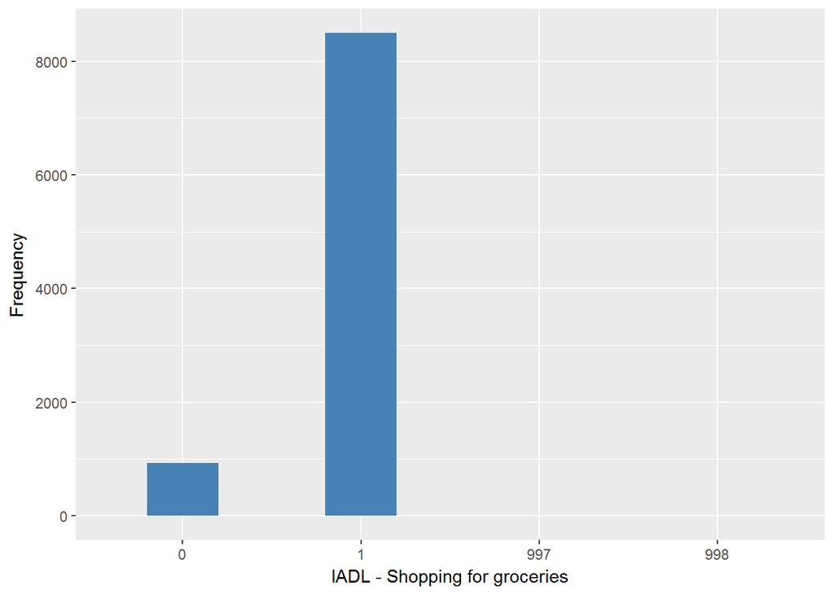

#### 2.1.2.4 Validation

|  | 1->0 | 0->1 | -9->997 | -8->998 |
| --- | --- | --- | --- | --- |
| BeforeH | 933 | 8496 | 2 | 1 |
| AfterH | 933 | 8496 | 2 | 1 |

### 2.1.3 Wave 3

#### 2.1.3.1 Study-specific variable description

The study-specific variables elected to be harmonised is:

- Name: `headlsh`
- Label: `IADL: Difficulty shopping for groceries`
- Categories:
- `0 = Not mentioned`
- `1 = Mentioned`
- Missings
- `-1 = Not applicable`

IADL - Difficulties for shopping groceries

| Sample size | Missing values |
| --- | --- |
| 9771 | 4 |

Category

|  | 0 | 1 |
| --- | --- | --- |
| Frequency | 8808.00 | 959.00 |
| Percentage | 90.14 | 9.81 |

Type of missing

|  | -1 | -9 | -8 | NA |
| --- | --- | --- | --- | --- |
| Frequency | 4.00 | 0 | 0 | 0 |
| Percentage | 0.04 | 0 | 0 | 0 |

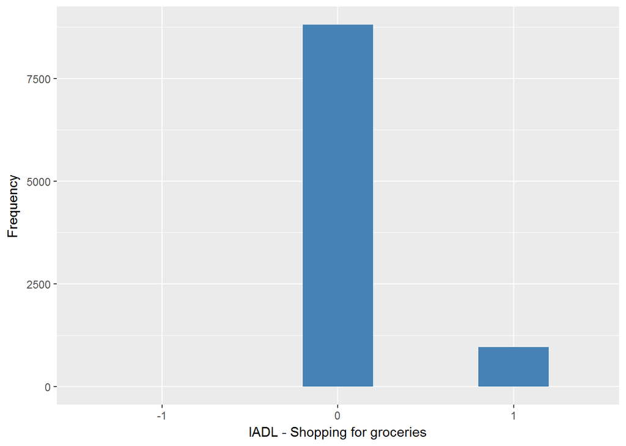

#### 2.1.3.2 Harmonisation algorithm

To compute the harmonize variable from the study-specific variable it has to be recoded as follows:

- `1 into 0`
- `0 into 1`
- `-1 Not applicable into 994`

**R script:**

```r
ELSA_ds_w3 <- tibble(id=ELSA_w3_iadl_shopping$id)
ELSA_ds_w3$iadl_shopping <- car::recode(ELSA_w3_iadl_shopping$headlsh, "0 = '1';1 = '0';-9 = '997';-8 = '998';-1 = '994' ")
ELSA_ds_w3$iadl_shopping <- labelled(ELSA_ds_w3$iadl_shopping, labels = c("Yes"=0, "No"=1,"Missing"=999, "Do not know"=998, "Refuse"=997, "Not applicable"=996, "Does not answer"=995,  "Not attempt not done"=994, "Disable to measure"=993, "Impute"=992, "CAPI interviewer error"=991))
```

#### 2.1.3.3 Statistical description of the new harmonised variable

IADL - Difficulties for shopping groceries

| Sample size | Missing values |
| --- | --- |
| 9771 | 4 |

Category

|  | 0 | 1 |
| --- | --- | --- |
| Frequency | 959.00 | 8808.00 |
| Percentage | 9.81 | 90.14 |

Type of missing

|  | 991 | 992 | 993 | 994 | 995 | 996 | 997 | 998 | 999 | NA |
| --- | --- | --- | --- | --- | --- | --- | --- | --- | --- | --- |
| Frequency | 0 | 0 | 0 | 4.00 | 0 | 0 | 0 | 0 | 0 | 0 |
| Percentage | 0 | 0 | 0 | 0.04 | 0 | 0 | 0 | 0 | 0 | 0 |

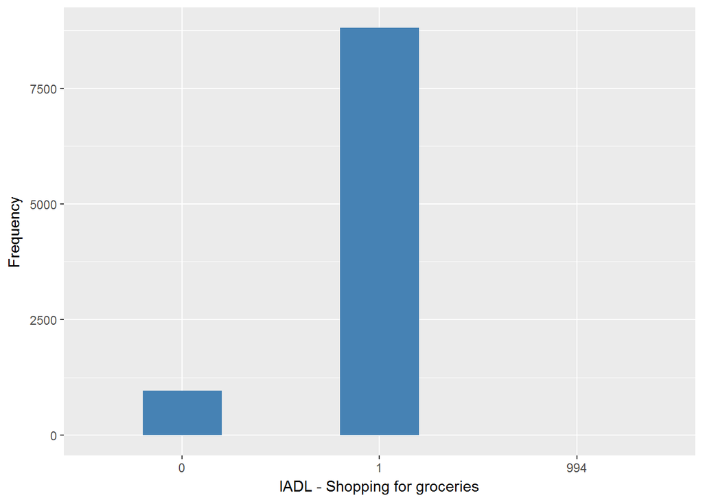

#### 2.1.3.4 Validation

|  | 1->0 | 0->1 | -1->994 |
| --- | --- | --- | --- |
| BeforeH | 959 | 8808 | 4 |
| AfterH | 959 | 8808 | 4 |

### 2.1.4 Wave 4

#### 2.1.4.1 Study-specific variable description

The study-specific variables elected to be harmonised is:

- Name: `headlsh`
- Label: `IADL: Difficulty shopping for groceries`
- Categories:
- `0 = Not mentioned`
- `1 = Mentioned`
- Missings
- `-9 = Refusal`
- `-8 = Don't know`

IADL - Difficulties for shopping groceries

| Sample size | Missing values |
| --- | --- |
| 11050 | 9 |

Category

|  | 0 | 1 |
| --- | --- | --- |
| Frequency | 10039.00 | 1002.00 |
| Percentage | 90.85 | 9.07 |

Type of missing

|  | -1 | -9 | -8 | NA |
| --- | --- | --- | --- | --- |
| Frequency | 0 | 7.00 | 2.00 | 0 |
| Percentage | 0 | 0.06 | 0.02 | 0 |

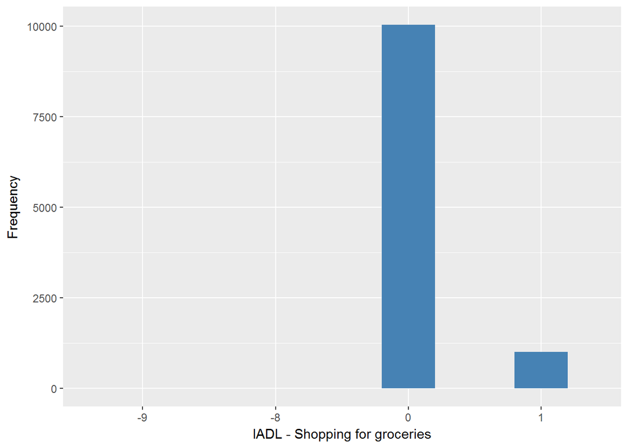

#### 2.1.4.2 Harmonisation algorithm

To compute the harmonize variable from the study-specific variable it has to be recoded as follows:

- `1 into 0`
- `0 into 1`
- `-9 Refusal into 997`
- `-8 Don't know into 998`

**R script:**

```r
ELSA_ds_w4 <- tibble(id=ELSA_w4_iadl_shopping$id)
ELSA_ds_w4$iadl_shopping <- car::recode(ELSA_w4_iadl_shopping$headlsh, "0 = '1';1 = '0';-9 = '997';-8 = '998';-1 = '994' ")
ELSA_ds_w4$iadl_shopping <- labelled(ELSA_ds_w4$iadl_shopping, labels = c("Yes"=0, "No"=1,"Missing"=999, "Do not know"=998, "Refuse"=997, "Not applicable"=996, "Does not answer"=995,  "Not attempt not done"=994, "Disable to measure"=993, "Impute"=992, "CAPI interviewer error"=991))
```

#### 2.1.4.3 Statistical description of the new harmonised variable

IADL - Difficulties for shopping groceries

| Sample size | Missing values |
| --- | --- |
| 11050 | 9 |

Category

|  | 0 | 1 |
| --- | --- | --- |
| Frequency | 1002.00 | 10039.00 |
| Percentage | 9.07 | 90.85 |

Type of missing

|  | 991 | 992 | 993 | 994 | 995 | 996 | 997 | 998 | 999 | NA |
| --- | --- | --- | --- | --- | --- | --- | --- | --- | --- | --- |
| Frequency | 0 | 0 | 0 | 0 | 0 | 0 | 7.00 | 2.00 | 0 | 0 |
| Percentage | 0 | 0 | 0 | 0 | 0 | 0 | 0.06 | 0.02 | 0 | 0 |

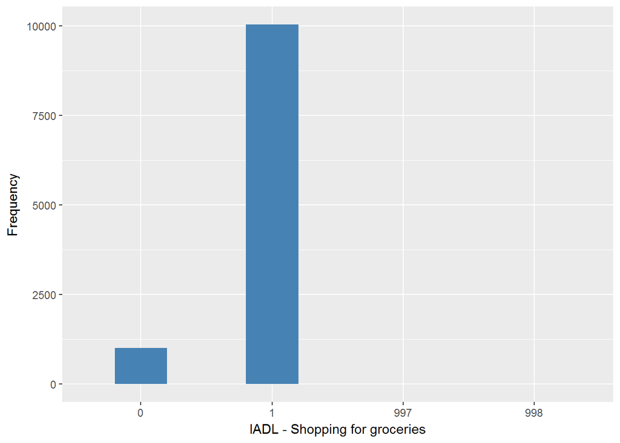

#### 2.1.4.4 Validation

|  | 1->0 | 0->1 | -9->997 | -8->998 |
| --- | --- | --- | --- | --- |
| BeforeH | 1002 | 10039 | 7 | 2 |
| AfterH | 1002 | 10039 | 7 | 2 |

### 2.1.5 Wave 5

#### 2.1.5.1 Study-specific variable description

The study-specific variables elected to be harmonised is:

- Name: `headlsh`
- Label: `IADL: Difficulty shopping for groceries`
- Categories:
- `0 = Not mentioned`
- `1 = Mentioned`
- Missings
- `-9 = Refusal`
- `-8 = Don't know`

IADL - Difficulties for shopping groceries

| Sample size | Missing values |
| --- | --- |
| 10274 | 8 |

Category

|  | 0 | 1 |
| --- | --- | --- |
| Frequency | 9259.00 | 1007.0 |
| Percentage | 90.12 | 9.8 |

Type of missing

|  | -1 | -9 | -8 | NA |
| --- | --- | --- | --- | --- |
| Frequency | 0 | 5.00 | 3.00 | 0 |
| Percentage | 0 | 0.05 | 0.03 | 0 |

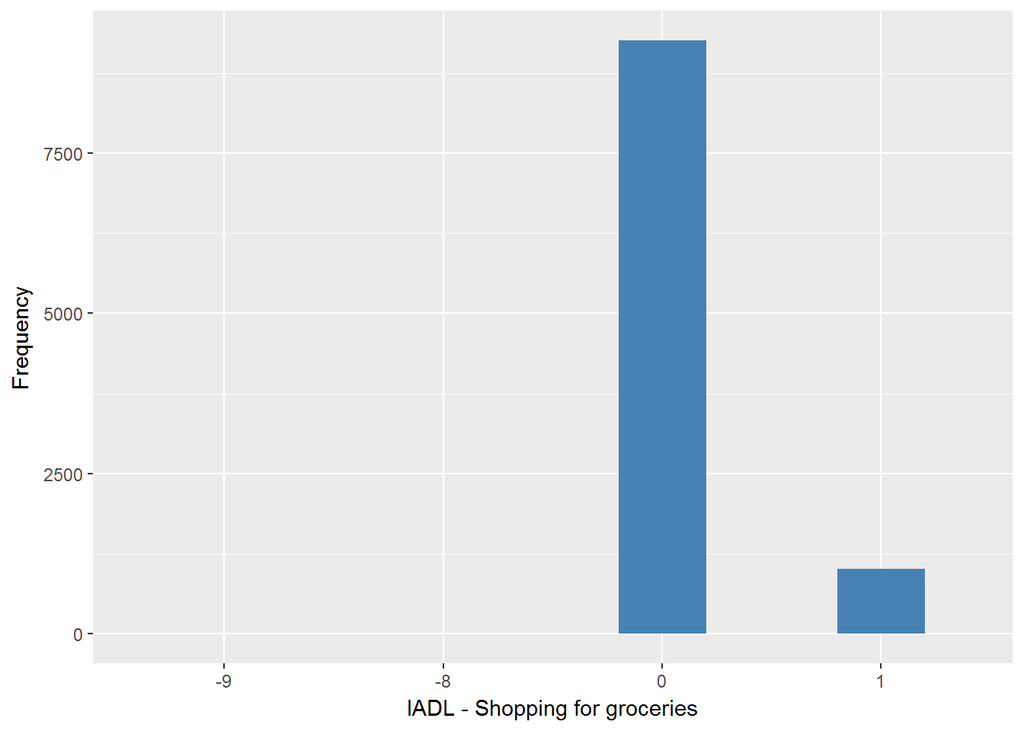

#### 2.1.5.2 Harmonisation algorithm

To compute the harmonize variable from the study-specific variable it has to be recoded as follows:

- `1 into 0`
- `0 into 1`
- `-9 Refusal into 997`
- `-8 Don't know into 998`

**R script:**

```r
ELSA_ds_w5 <- tibble(id=ELSA_w5_iadl_shopping$id)
ELSA_ds_w5$iadl_shopping <- car::recode(ELSA_w5_iadl_shopping$headlsh, "0 = '1';1 = '0';-9 = '997';-8 = '998';-1 = '994' ")
ELSA_ds_w5$iadl_shopping <- labelled(ELSA_ds_w5$iadl_shopping, labels = c("Yes"=0, "No"=1,"Missing"=999, "Do not know"=998, "Refuse"=997, "Not applicable"=996, "Does not answer"=995,  "Not attempt not done"=994, "Disable to measure"=993, "Impute"=992, "CAPI interviewer error"=991))
```

#### 2.1.5.3 Statistical description of the new harmonised variable

IADL - Difficulties for shopping groceries

| Sample size | Missing values |
| --- | --- |
| 10274 | 8 |

Category

|  | 0 | 1 |
| --- | --- | --- |
| Frequency | 1007.0 | 9259.00 |
| Percentage | 9.8 | 90.12 |

Type of missing

|  | 991 | 992 | 993 | 994 | 995 | 996 | 997 | 998 | 999 | NA |
| --- | --- | --- | --- | --- | --- | --- | --- | --- | --- | --- |
| Frequency | 0 | 0 | 0 | 0 | 0 | 0 | 5.00 | 3.00 | 0 | 0 |
| Percentage | 0 | 0 | 0 | 0 | 0 | 0 | 0.05 | 0.03 | 0 | 0 |

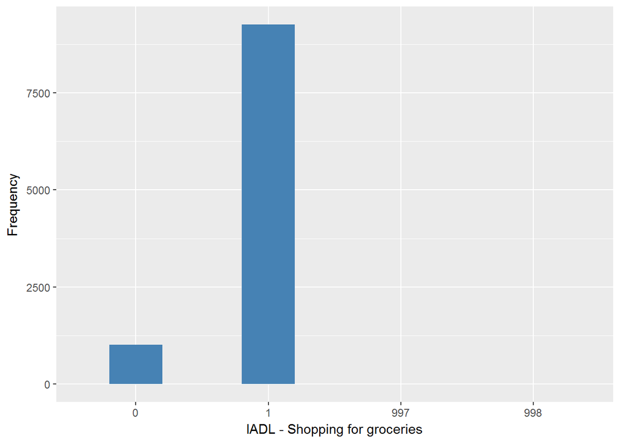

#### 2.1.5.4 Validation

|  | 1->0 | 0->1 | -9->997 | -8->998 |
| --- | --- | --- | --- | --- |
| BeforeH | 1007 | 9259 | 5 | 3 |
| AfterH | 1007 | 9259 | 5 | 3 |

### 2.1.6 Wave 6

#### 2.1.6.1 Study-specific variable description

The study-specific variables elected to be harmonised is:

- Name: `headlsh`
- Label: `IADL: Difficulty shopping for groceries`
- Categories:
- `0 = Not mentioned`
- `1 = Mentioned`
- Missings
- `-9 = Refusal`
- `-8 = Don't know`

IADL - Difficulties for shopping groceries

| Sample size | Missing values |
| --- | --- |
| 10601 | 5 |

Category

|  | 0 | 1 |
| --- | --- | --- |
| Frequency | 9598.00 | 998.00 |
| Percentage | 90.54 | 9.41 |

Type of missing

|  | -1 | -9 | -8 | NA |
| --- | --- | --- | --- | --- |
| Frequency | 0 | 3.00 | 2.00 | 0 |
| Percentage | 0 | 0.03 | 0.02 | 0 |

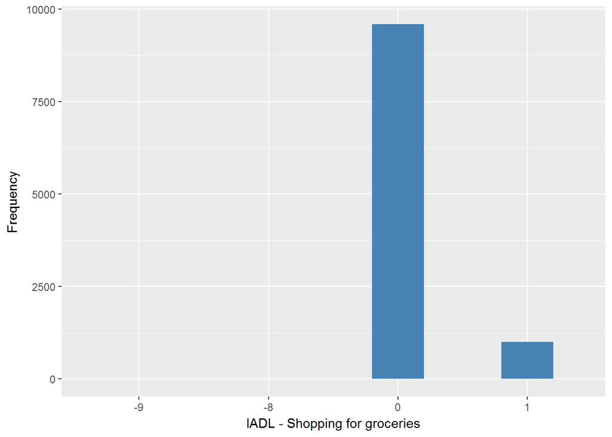

#### 2.1.6.2 Harmonisation algorithm

To compute the harmonize variable from the study-specific variable it has to be recoded as follows:

- `1 into 0`
- `0 into 1`
- `-9 Refusal into 997`
- `-8 Don't know into 998`

**R script:**

```r
ELSA_ds_w6 <- tibble(id=ELSA_w6_iadl_shopping$id)
ELSA_ds_w6$iadl_shopping <- car::recode(ELSA_w6_iadl_shopping$headlsh, "0 = '1';1 = '0';-9 = '997';-8 = '998';-1 = '994' ")
ELSA_ds_w6$iadl_shopping <- labelled(ELSA_ds_w6$iadl_shopping, labels = c("Yes"=0, "No"=1,"Missing"=999, "Do not know"=998, "Refuse"=997, "Not applicable"=996, "Does not answer"=995,  "Not attempt not done"=994, "Disable to measure"=993, "Impute"=992, "CAPI interviewer error"=991))
```

#### 2.1.6.3 Statistical description of the new harmonised variable

IADL - Difficulties for shopping groceries

| Sample size | Missing values |
| --- | --- |
| 10601 | 5 |

Category

|  | 0 | 1 |
| --- | --- | --- |
| Frequency | 998.00 | 9598.00 |
| Percentage | 9.41 | 90.54 |

Type of missing

|  | 991 | 992 | 993 | 994 | 995 | 996 | 997 | 998 | 999 | NA |
| --- | --- | --- | --- | --- | --- | --- | --- | --- | --- | --- |
| Frequency | 0 | 0 | 0 | 0 | 0 | 0 | 3.00 | 2.00 | 0 | 0 |
| Percentage | 0 | 0 | 0 | 0 | 0 | 0 | 0.03 | 0.02 | 0 | 0 |

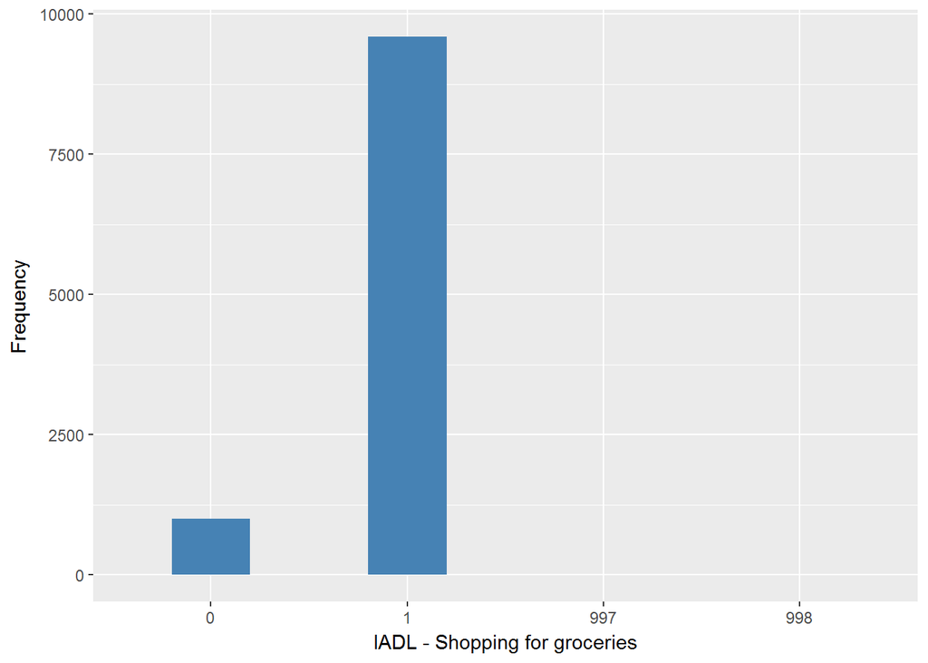

#### 2.1.6.4 Validation

|  | 1->0 | 0->1 | -9->997 | -8->998 |
| --- | --- | --- | --- | --- |
| BeforeH | 998 | 9598 | 3 | 2 |
| AfterH | 998 | 9598 | 3 | 2 |

### 2.1.7 Wave 7

#### 2.1.7.1 Study-specific variable description

The study-specific variables elected to be harmonised is:

- Name: `headlsh`
- Label: `IADL: Difficulty shopping for groceries`
- Categories:
- `0 = Not mentioned`
- `1 = Mentioned`
- Missings
- `-8 = Don't know`

IADL - Difficulties for shopping groceries

| Sample size | Missing values |
| --- | --- |
| 9666 | 2 |

Category

|  | 0 | 1 |
| --- | --- | --- |
| Frequency | 8786.0 | 878.00 |
| Percentage | 90.9 | 9.08 |

Type of missing

|  | -1 | -9 | -8 | NA |
| --- | --- | --- | --- | --- |
| Frequency | 0 | 0 | 2.00 | 0 |
| Percentage | 0 | 0 | 0.02 | 0 |

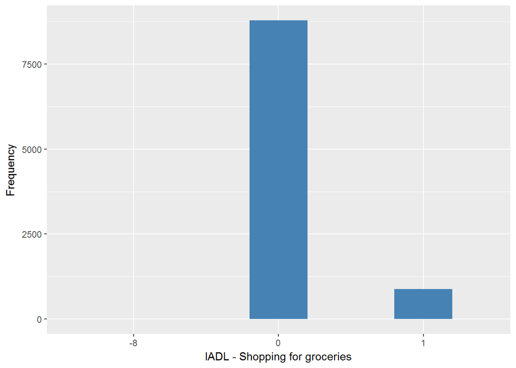

#### 2.1.7.2 Harmonisation algorithm

To compute the harmonize variable from the study-specific variable it has to be recoded as follows:

- `1 into 0`
- `0 into 1`
- `-8 Don't know into 998`

**R script:**

```r
ELSA_ds_w7 <- tibble(id=ELSA_w7_iadl_shopping$id)
ELSA_ds_w7$iadl_shopping <- car::recode(ELSA_w7_iadl_shopping$headlsh, "0 = '1';1 = '0';-9 = '997';-8 = '998';-1 = '994' ")
ELSA_ds_w7$iadl_shopping <- labelled(ELSA_ds_w7$iadl_shopping, labels = c("Yes"=0, "No"=1,"Missing"=999, "Do not know"=998, "Refuse"=997, "Not applicable"=996, "Does not answer"=995,  "Not attempt not done"=994, "Disable to measure"=993, "Impute"=992, "CAPI interviewer error"=991))
```

#### 2.1.7.3 Statistical description of the new harmonised variable

IADL - Difficulties for shopping groceries

| Sample size | Missing values |
| --- | --- |
| 9666 | 2 |

Category

|  | 0 | 1 |
| --- | --- | --- |
| Frequency | 878.00 | 8786.0 |
| Percentage | 9.08 | 90.9 |

Type of missing

|  | 991 | 992 | 993 | 994 | 995 | 996 | 997 | 998 | 999 | NA |
| --- | --- | --- | --- | --- | --- | --- | --- | --- | --- | --- |
| Frequency | 0 | 0 | 0 | 0 | 0 | 0 | 0 | 2.00 | 0 | 0 |
| Percentage | 0 | 0 | 0 | 0 | 0 | 0 | 0 | 0.02 | 0 | 0 |

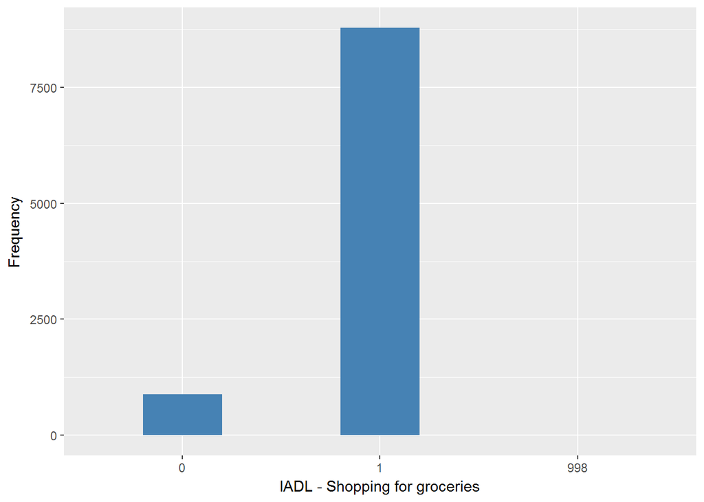

#### 2.1.7.4 Validation

|  | 1->0 | 0->1 | -8->998 |
| --- | --- | --- | --- |
| BeforeH | 878 | 8786 | 2 |
| AfterH | 878 | 8786 | 2 |

# 3 Quality estimation

No comments

### 3.0.1 Summary of descriptive statistics of the harmonised variable accross populations and waves

Two tables are generated:

1. Percentages of categories in each harmonised variable.
2. Frequencies and percentages of individuals with different trajectories. To avoid too large table, Only trajectories with percentages larger than 0.3 are shown.

```r
ELSA_ds_w1$iadl_shopping <- labelled(ELSA_ds_w1$iadl_shopping, labels = c(Presence=0, Absence=1, Missing=999, Do_not_know=998, Refuse=997, Not_attempt_not_done=996, Does_not_answer=995,  Not_applicable=994, Disable_to_measure=993, Impute=992, CAPI_interviewer_error=991))
ELSA_ds_w2$iadl_shopping <- labelled(ELSA_ds_w2$iadl_shopping, labels = c(Presence=0, Absence=1, Missing=999, Do_not_know=998, Refuse=997, Not_attempt_not_done=996, Does_not_answer=995,  Not_applicable=994, Disable_to_measure=993, Impute=992, CAPI_interviewer_error=991))
ELSA_ds_w3$iadl_shopping <- labelled(ELSA_ds_w3$iadl_shopping, labels = c(Presence=0, Absence=1, Missing=999, Do_not_know=998, Refuse=997, Not_attempt_not_done=996, Does_not_answer=995,  Not_applicable=994, Disable_to_measure=993, Impute=992, CAPI_interviewer_error=991))
ELSA_ds_w4$iadl_shopping <- labelled(ELSA_ds_w4$iadl_shopping, labels = c(Presence=0, Absence=1, Missing=999, Do_not_know=998, Refuse=997, Not_attempt_not_done=996, Does_not_answer=995,  Not_applicable=994, Disable_to_measure=993, Impute=992, CAPI_interviewer_error=991))
ELSA_ds_w5$iadl_shopping <- labelled(ELSA_ds_w5$iadl_shopping, labels = c(Presence=0, Absence=1, Missing=999, Do_not_know=998, Refuse=997, Not_attempt_not_done=996, Does_not_answer=995,  Not_applicable=994, Disable_to_measure=993, Impute=992, CAPI_interviewer_error=991))
ELSA_ds_w6$iadl_shopping <- labelled(ELSA_ds_w6$iadl_shopping, labels = c(Presence=0, Absence=1, Missing=999, Do_not_know=998, Refuse=997, Not_attempt_not_done=996, Does_not_answer=995,  Not_applicable=994, Disable_to_measure=993, Impute=992, CAPI_interviewer_error=991))
ELSA_ds_w7$iadl_shopping <- labelled(ELSA_ds_w7$iadl_shopping, labels = c(Presence=0, Absence=1, Missing=999, Do_not_know=998, Refuse=997, Not_attempt_not_done=996, Does_not_answer=995,  Not_applicable=994, Disable_to_measure=993, Impute=992, CAPI_interviewer_error=991))

tt <-    frq(ELSA_ds_w1$iadl_shopping)[[1]][,c(1:2,4)]
tt[4] <- frq(ELSA_ds_w2$iadl_shopping)[[1]][,c(4)]
tt[5] <- frq(ELSA_ds_w3$iadl_shopping)[[1]][,c(4)]
tt[6] <- frq(ELSA_ds_w4$iadl_shopping)[[1]][,c(4)]
tt[7] <- frq(ELSA_ds_w5$iadl_shopping)[[1]][,c(4)]
tt[8] <- frq(ELSA_ds_w6$iadl_shopping)[[1]][,c(4)]
tt[9] <- frq(ELSA_ds_w7$iadl_shopping)[[1]][,c(4)]
tt[13,] <- c("n", "sample size",
             length(ELSA_ds_w1$iadl_shopping), length(ELSA_ds_w2$iadl_shopping), length(ELSA_ds_w3$iadl_shopping),
             length(ELSA_ds_w4$iadl_shopping), length(ELSA_ds_w5$iadl_shopping), length(ELSA_ds_w6$iadl_shopping),
             length(ELSA_ds_w7$iadl_shopping))
names(tt)<-c("val", "label", "w1", "w2", "w3", "w4", "w5", "w6", "w7")
kable(tt)
```

| val | label | w1 | w2 | w3 | w4 | w5 | w6 | w7 |
| --- | --- | --- | --- | --- | --- | --- | --- | --- |
| 0 | Presence | 9.15 | 9.89 | 9.81 | 9.07 | 9.8 | 9.41 | 9.08 |
| 1 | Absence | 89.27 | 90.08 | 90.14 | 90.85 | 90.12 | 90.54 | 90.9 |
| 991 | CAPI_interviewer_error | 0 | 0 | 0 | 0 | 0 | 0 | 0 |
| 992 | Impute | 0 | 0 | 0 | 0 | 0 | 0 | 0 |
| 993 | Disable_to_measure | 0 | 0 | 0 | 0 | 0 | 0 | 0 |
| 994 | Not_applicable | 1.45 | 0 | 0.04 | 0 | 0 | 0 | 0 |
| 995 | Does_not_answer | 0 | 0 | 0 | 0 | 0 | 0 | 0 |
| 996 | Not_attempt_not_done | 0 | 0 | 0 | 0 | 0 | 0 | 0 |
| 997 | Refuse | 0.03 | 0.02 | 0 | 0.06 | 0.05 | 0.03 | 0 |
| 998 | Do_not_know | 0.1 | 0.01 | 0 | 0.02 | 0.03 | 0.02 | 0.02 |
| 999 | Missing | 0 | 0 | 0 | 0 | 0 | 0 | 0 |
| NA | NA | 0 | 0 | 0 | 0 | 0 | 0 | 0 |
| n | sample size | 12099 | 9432 | 9771 | 11050 | 10274 | 10601 | 9666 |

```r
dbb <- merge(ELSA_m_ds_w1, ELSA_m_ds_w2, by="id", suffixes = c(".w1",".w2"), all=T)
dbb <- merge(dbb, ELSA_m_ds_w3, by="id", all=T)
dbb <- merge(dbb, ELSA_m_ds_w4, by="id", suffixes = c(".w3",".w4"), all=T)
dbb <- merge(dbb, ELSA_m_ds_w5, by="id", all=T)
dbb <- merge(dbb, ELSA_m_ds_w6, by="id", suffixes = c(".w5",".w6"), all=T)
dbb <- merge(dbb, ELSA_m_ds_w7, by="id", all=T)
names(dbb) <- c("id", "w1", "w2", "w3", "w4", "w5", "w6", "w7")
v.dbb <- paste(dbb[,2],dbb[,3],dbb[,4],dbb[,5],dbb[,6],dbb[,7],dbb[,8],sep="")
f.dbb <- frq(v.dbb)[[1]][,c(1,2,4)]
kable(f.dbb[f.dbb[,3]>=0.3,])
```

|  | val | frq | raw.prc |
| --- | --- | --- | --- |
| 32 | 000NANANANA | 66 | 0.36 |
| 72 | 00NANANANANA | 94 | 0.51 |
| 173 | 0NANANANANANA | 335 | 1.81 |
| 258 | 10NANANANANA | 124 | 0.67 |
| 304 | 110NANANANA | 76 | 0.41 |
| 325 | 1110NANANA | 67 | 0.36 |
| 333 | 11110NANA | 57 | 0.31 |
| 335 | 1111101 | 56 | 0.30 |
| 337 | 1111110 | 137 | 0.74 |
| 338 | 1111111 | 3509 | 18.98 |
| 339 | 111111NA | 447 | 2.42 |
| 342 | 11111NANA | 282 | 1.53 |
| 351 | 1111NANANA | 413 | 2.23 |
| 361 | 111NA111 | 93 | 0.50 |
| 370 | 111NANANANA | 653 | 3.53 |
| 387 | 11NA1111 | 95 | 0.51 |
| 412 | 11NANANANANA | 992 | 5.37 |
| 439 | 1NA11111 | 74 | 0.40 |
| 457 | 1NA1NANANANA | 70 | 0.38 |
| 476 | 1NANA1111 | 57 | 0.31 |
| 505 | 1NANANANANANA | 1664 | 9.00 |
| 607 | NANA11111 | 766 | 4.14 |
| 608 | NANA1111NA | 106 | 0.57 |
| 611 | NANA111NANA | 81 | 0.44 |
| 619 | NANA11NANANA | 114 | 0.62 |
| 631 | NANA1NANANANA | 292 | 1.58 |
| 666 | NANANA1111 | 1498 | 8.10 |
| 667 | NANANA111NA | 212 | 1.15 |
| 670 | NANANA11NANA | 149 | 0.81 |
| 679 | NANANA1NANANA | 323 | 1.75 |
| 685 | NANANANA111 | 75 | 0.41 |
| 693 | NANANANANA11 | 883 | 4.78 |
| 694 | NANANANANA1NA | 256 | 1.38 |
| 696 | NANANANANANA1 | 486 | 2.63 |
| 697 | NANANANANANANA | 92 | 0.50 |